# Atividade 4

Marina Méga

16/05/2022

## Ocorrência de *Lottia subrugosa*

Atividade 4 feita para a disciplina “Base de Dados e Colaboração” da Pós-graduação em Ecologia da UENF. Foram acessados dois bancos de dados (Gbif e Obis) para obter informações de *L. subrugosa*, os dados foram inspecionados e avaliados. Por fim, foi realizado um mapa com as ocorrências.

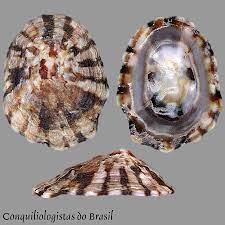

Figura 1: *Lottia subrugosa*. Fonte: Conchas do Brasil

Como os dados foram manipulados, foi necessária a utilização do pacote `tidyverse`. Da mesma forma, o pacote `rgbif` foi utilizado para iniciar a busca no banco Gbif.

## 1. GBIF

### 1.1 Introdução

#### Carregando os pacotes

```r
library(tidyverse)
library(rgbif)
```

#### Carregamento do Banco de Dados

```r
# baixar ocorrencias
lsub_gbif <- occ_data(scientificName = "Lottia subrugosa",
                      hasCoordinate = TRUE,
                      hasGeospatialIssue=FALSE)
#dimensoes
dim(lsub_gbif)
```

```r
dim(lsub_gbif$data)
```

```
## [1] 405 139
```

```r
# checando campos
lsub_gbif$data %>% names
```

```
##   [1] "key"                            "scientificName"
##   [3] "decimalLatitude"                "decimalLongitude"
##   [5] "issues"                         "datasetKey"
##   [7] "publishingOrgKey"               "installationKey"
##   [9] "publishingCountry"              "protocol"
##  [11] "lastCrawled"                    "lastParsed"
##  [13] "crawlId"                        "hostingOrganizationKey"
##  [15] "basisOfRecord"                  "occurrenceStatus"
##  [17] "taxonKey"                       "kingdomKey"
##  [19] "phylumKey"                      "classKey"
##  [21] "familyKey"                      "genusKey"
##  [23] "speciesKey"                     "acceptedTaxonKey"
##  [25] "acceptedScientificName"         "kingdom"
##  [27] "phylum"                         "family"
##  [29] "genus"                          "species"
```

[output cut: 55 more lines]

### 1.2 Verificando “issues” reportados

O validador automático do repositório já consegue identificar alguns problemas (issues). Podemos conferir o código destes Os problemas (issues) pela função gbif_issues.

```r
### problemas relatados
lsub_gbif$data$issues
```

```
##   [1] "cdround"                     "cdround"
##   [3] "cdround"                     "cdround"
##   [5] "cdround"                     "cdround"
##   [7] "cdround"                     "cdround"
##   [9] "cdround"                     "cdround"
##  [11] "cdround"                     "cdround"
##  [13] "cdround"                     "cdround"
##  [15] "cdround"                     "cdround"
##  [17] "cdround"                     "cdround"
##  [19] "cdround"                     "cdround"
##  [21] "cdround"                     "cdround"
##  [23] "gass84,osiic,incomis,inmafu" "gass84,osiic,incomis,inmafu"
##  [25] ""                            "cdround"
##  [27] "cdround"                     "cdround"
##  [29] "gass84,osiic,ambinst"        "gass84,osiic,ambinst"
```

[output cut: 188 more lines]

```r
lsub_gbif$data$issues %>%
  unique()
```

```
##  [1] "cdround"                     "gass84,osiic,incomis,inmafu"
##  [3] ""                            "gass84,osiic,ambinst"
##  [5] "gass84"                      "gass84,rdativ,osiic,ambinst"
##  [7] "cdround,gass84,osiic,inmano" "colmafu,inmafu"
##  [9] "iccos,colmafu,inmafu"        "txmatfuz,colmafu,inmafu"
## [11] "osiic,incomis,inmafu"        "cdround,gass84,inmano"
## [13] "ambcol"
```

```r
# Para individualizar os issues e poder conferí-los utilizamos a função strsplit
issues_gbif<- lsub_gbif$data$issues %>%
  unique() %>%
  strsplit(., "[,]") %>%
  unlist()

gbif_issues() %>%
  data.frame() %>%
  filter(code %in% issues_gbif)
```

```
##        code                                             issue
## 1   cdround                                COORDINATE_ROUNDED
## 2    gass84                      GEODETIC_DATUM_ASSUMED_WGS84
## 3    rdativ                             RECORDED_DATE_INVALID
## 4  txmatfuz                                 TAXON_MATCH_FUZZY
## 5     iccos INDIVIDUAL_COUNT_CONFLICTS_WITH_OCCURRENCE_STATUS
## 6     osiic  OCCURRENCE_STATUS_INFERRED_FROM_INDIVIDUAL_COUNT
## 7    ambcol                              AMBIGUOUS_COLLECTION
## 8   ambinst                             AMBIGUOUS_INSTITUTION
## 9   colmafu                            COLLECTION_MATCH_FUZZY
## 10  incomis                   INSTITUTION_COLLECTION_MISMATCH
## 11   inmafu                           INSTITUTION_MATCH_FUZZY
## 12   inmano                            INSTITUTION_MATCH_NONE
##                                                                                                                                 description
## 1                                                                                   Original coordinate modified by rounding to 5 decimals.
```

[output cut: 24 more lines]

Agora iremos selecionar algumas variáveis que podem ser úteis para a validação dos dados e futuras análises, como coordenadas, profundidade, nome da base de dados etc.

```r
lsub_gbif1 <- lsub_gbif$data %>%
  dplyr::select(scientificName, acceptedScientificName, decimalLatitude, decimalLongitude,
                issues, waterBody, basisOfRecord, occurrenceStatus, rightsHolder,
                datasetName, recordedBy, depth, locality, habitat)
```

Note que temos cerca de 405 observações, mas é preciso verificar quantas são únicas

```r
# Verificando quantas ocorrências são únicas
lsub_gbif1 <- lsub_gbif1 %>%
  distinct()
```

Restaram apenas 163 observações.

Em seguida, foi aplicada a função `unique` a cada coluna com um loop na função `lapply` afim de identificar todos os valores únicos presentes nos dados

```r
# checando niveis dos fatores
lapply(lsub_gbif1, unique)
```

```
## $scientificName
## [1] "Lottia subrugosa (d'Orbigny, 1846)"
## [2] "Collisella subrugosa (d'Orbigny, 1846)"
## [3] "Lottia onychina Gould, 1852"
##
## $acceptedScientificName
## [1] "Lottia subrugosa (d'Orbigny, 1846)"
##
## $decimalLatitude
##   [1] -26.794262 -26.757459 -20.333822 -22.740769 -22.740777 -23.831261
##   [7] -22.974237 -20.819607 -12.952108 -12.491010 -20.287377 -23.769028
##  [13]  -7.905661 -11.803522 -14.275432 -12.952894 -25.850500 -28.018342
##  [19]  -6.372035 -23.765219 -26.768940 -34.650350 -34.655383 -23.871885
##  [25] -27.749747 -20.333561 -23.815839 -23.069393 -23.029296 -29.358360
##  [31] -27.882500 -27.865060 -29.347080 -29.351670 -27.850000 -34.969590
```

[output cut: 282 more lines]

### 1.3 Verificando “issues” **não** reportados

A validação mais “fina” não é realizada pelo algoritmo. Por isso, é necessário realizar manualmente a checagem de “issues” não reportados.  
Primeiro, as coordenadas foram verificadas utilizando funções dos pacotes `CoordinateCleaner` e `bcd`

```r
library(bdc)
library(CoordinateCleaner)
```

```r
# checando coordenadas válidas
check_pf <-
  bdc::bdc_coordinates_outOfRange(
    data = lsub_gbif1,
    lat = "decimalLatitude",
    lon = "decimalLongitude")
```

```
##
## bdc_coordinates_outOfRange:
## Flagged 0 records.
## One column was added to the database.
```

```r
# checar coordenadas válidas e próximas a capitais (muitas vezes as coordenadas são erroneamente associadas a capitais dos países)

cl <- lsub_gbif1 %>%
  select(acceptedScientificName, decimalLatitude, decimalLongitude) %>%
  rename(decimallongitude = decimalLongitude,
         decimallatitude = decimalLatitude,
         scientificName = acceptedScientificName) %>%
  as_tibble() %>%
  mutate(val = cc_val(., value = "flagged"),
         sea = cc_sea(., value = "flagged"),
         capital = cc_cap(., value = "flagged"))
```

```
## Testing coordinate validity
```

```
## Flagged 0 records.
```

```
## Testing sea coordinates
```

```
## Flagged 43 records.
```

```
## Testing country capitals
```

```
## Flagged 0 records.
```

Agora será possível observar no mapa plotado caso haja algum ponto muito dentro do continente. Por ser uma espécie do entre-marés, desconsideramos agora apenas os pontos que estão localizados fora da linha de costa, mesmo que estivessem em continente.

```r
# verificar coordenadas com flags

# capitais (padrão é um raio de 10km)
 cl %>%
  rename(decimalLongitude = decimallongitude,
         decimalLatitude = decimallatitude) %>%
  bdc::bdc_quickmap(., col_to_map = "capital")
```

[figure not shown]

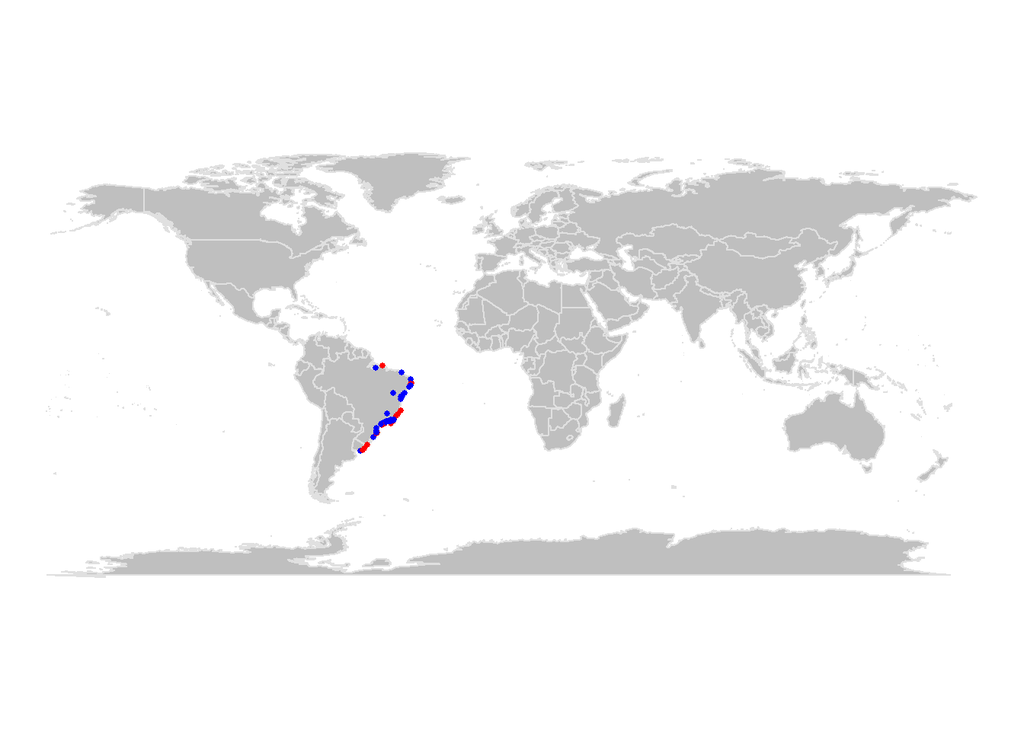

```r
cl %>%
  rename(decimalLongitude = decimallongitude,
         decimalLatitude = decimallatitude) %>%
  bdc::bdc_quickmap(., col_to_map = "sea")
```

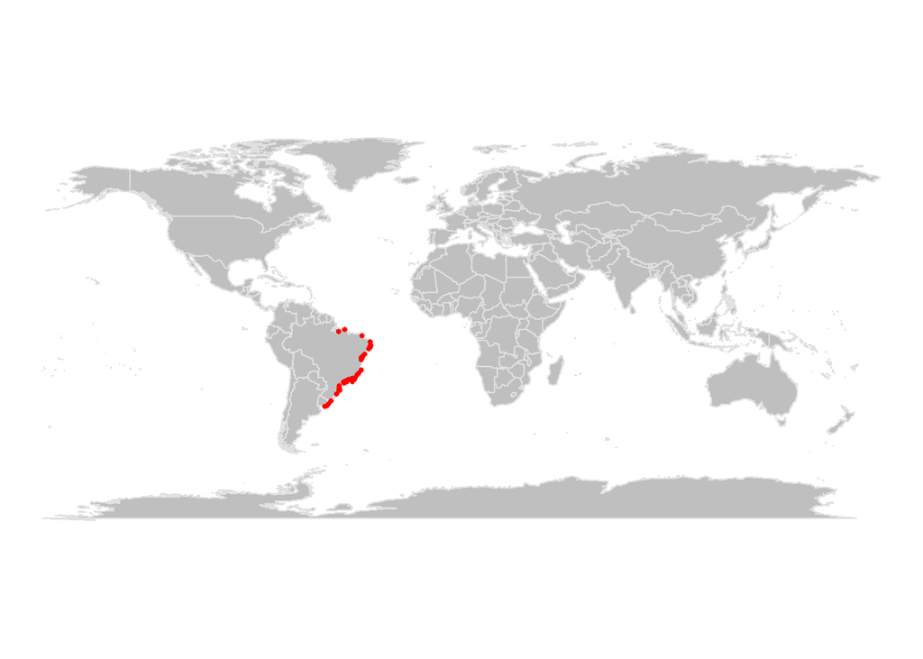

```r
##### Excluindo manualmente os pontos muito dentro do continente
cl2<- cl[-c(146, 147, 150, 154),]


cl2 %>%
  rename(decimalLongitude = decimallongitude,
         decimalLatitude = decimallatitude) %>%
  bdc::bdc_quickmap(., col_to_map = "capital")
```

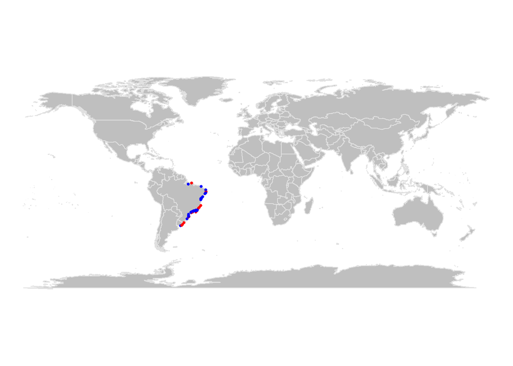

```r
cl2 %>%
  rename(decimalLongitude = decimallongitude,
         decimalLatitude = decimallatitude) %>%
  bdc::bdc_quickmap(., col_to_map = "sea")
```

Podemos identificar também em quais corpos d’água *L. subrugosa* foi registrada no repositório.

```r
# investigar niveis suspeitos
lsub_gbif1 %>%
  distinct(waterBody) %>%
  pull()
```

```
## [1] NA                    "Oceano Atlântico"    "Atlantic Ocean"
## [4] "Atlantic, Southwest"
```

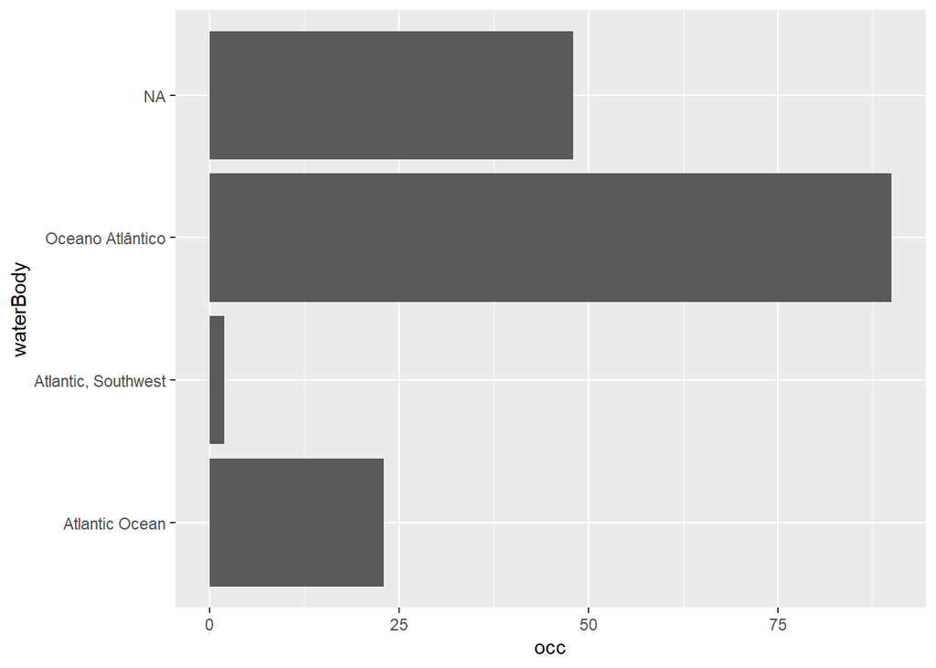

```r
# waterBody
lsub_gbif1 %>%
  group_by(waterBody) %>%
  summarise(occ = length(scientificName)) %>%
  ggplot(aes(occ, y=waterBody)) +
  geom_bar(stat = 'identity')
```

Note que ocorre apenas no Atlântico e suas coordenadas no mapa correspondem à distribuição conhecida para a espécie. Dessa forma, não foi necessário realizar a filtragem por regiões erradas. Entretanto, ainda não retiramos do dataframe as coordenadas dentro dos continentes, para isso:

```r
# Retirando os pontos dentro do continente do dataset
lsub_gbif_ok <- lsub_gbif1[-c(146, 147, 150, 154),]
```

Para plotar o mapa com as coordenadas validadas até aqui:

```r
# chamando pacotes necessários
library(ggmap)
```

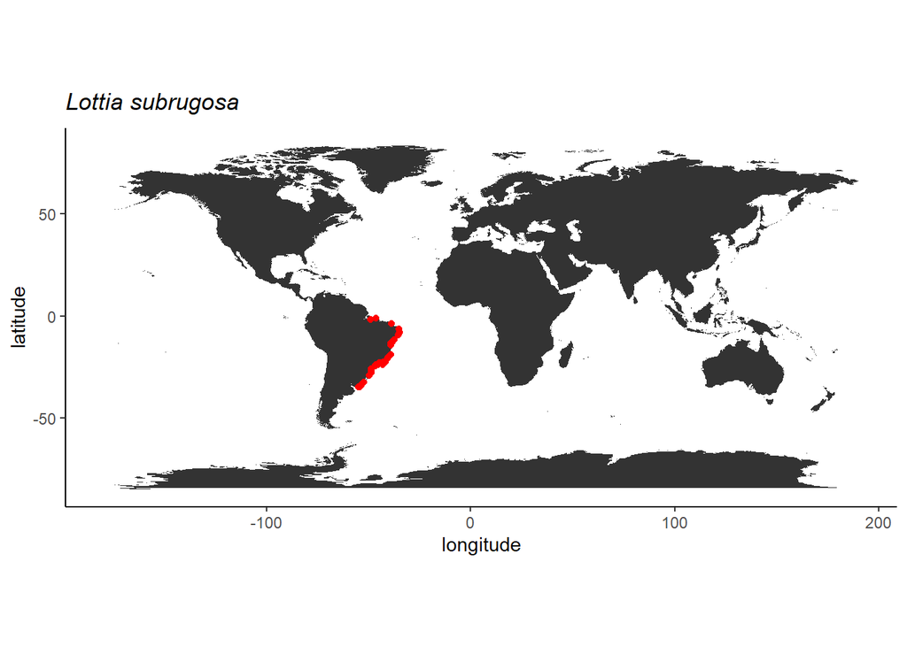

```r
library(maps)
library(mapdata)
world <- map_data('world')

ggplot() +
  geom_polygon(data = world, aes(x = long, y = lat, group = group)) +
  coord_fixed() +
  theme_classic() +
  geom_point(data = lsub_gbif_ok, aes(x = decimalLongitude, y = decimalLatitude), color = "red") +
  labs(x = "longitude", y = "latitude", title = expression(italic("Lottia subrugosa")))
```

Outro modo de filtrar pode ser a profundidade, mas neste caso tinham poucas informações no gbif. Note que foi encontrado registro à 25m de profundidade e, apesar de ser considerada uma espécie predominantemente do entre-marés, existe ocorrência registrada para profundidades maiores. Por isso, essa ocorrência não foi retirada.

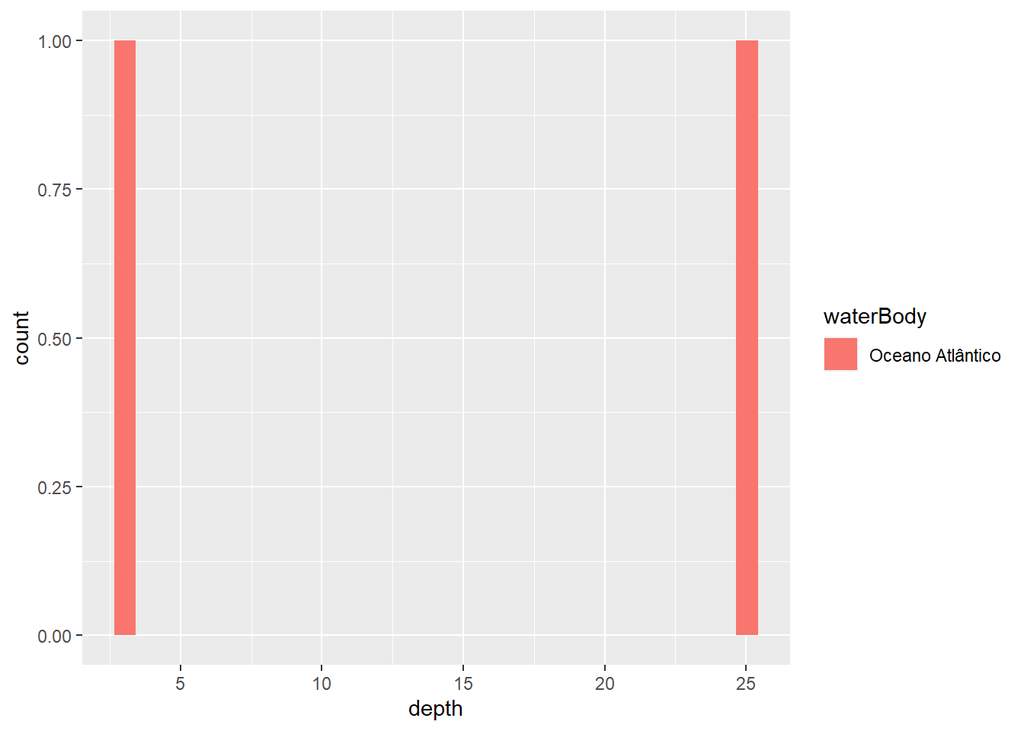

```r
# checar profundidade
lsub_gbif_ok %>%
  ggplot(aes(x = depth, fill = waterBody)) +
  geom_histogram()
```

## 2. OBIS

Passando agora para o outro repositório, vamos repetir todo o processo de baixar e checar os dados

```r
library(robis)
lsub_obis <- robis::occurrence("Lottia subrugosa")
```

```
## Retrieved 5000 records of approximately 7146 (69%) Retrieved 7146 records of
## approximately 7146 (100%)
```

```r
# checar dados
names(lsub_obis)
```

```
##  [1] "country"                       "eventID"
##  [3] "date_year"                     "habitat"
##  [5] "scientificNameID"              "scientificName"
##  [7] "absence"                       "subfamily"
##  [9] "superfamilyid"                 "dropped"
## [11] "genusid"                       "aphiaID"
## [13] "decimalLatitude"               "subclassid"
## [15] "originalScientificName"        "marine"
## [17] "phylumid"                      "familyid"
## [19] "subfamilyid"                   "occurrenceStatus"
## [21] "basisOfRecord"                 "date_mid"
## [23] "tribeid"                       "id"
## [25] "class"                         "dataset_id"
## [27] "locality"                      "verbatimCoordinateSystem"
## [29] "decimalLongitude"              "geodeticDatum"
```

[output cut: 34 more lines]

```r
lsub_obis1 <- lsub_obis %>%
  dplyr::select(scientificName, decimalLatitude, decimalLongitude, bathymetry,
                flags, waterBody, basisOfRecord, occurrenceStatus, rightsHolder,
                datasetName, recordedBy, depth, locality, habitat) %>%
  distinct()
```

### 2.1 “Issues” reportados

```r
# check problemas reportados (flags)
lsub_obis1 %>%
  distinct(flags)
```

```
## # A tibble: 7 x 1
##   flags
##   <chr>
## 1 NO_DEPTH
## 2 NO_DEPTH,ON_LAND
## 3 ON_LAND,NO_DEPTH
## 4 <NA>
## 5 DEPTH_EXCEEDS_BATH
## 6 ON_LAND,DEPTH_EXCEEDS_BATH
## 7 ON_LAND
```

```r
# retirando certos flags
lsub_obis1 %>%
  filter(!flags %in% c('no_depht', 'depth_exceeds_bath'),
         is.na(datasetName)) %>%
  distinct(waterBody)
```

```
## # A tibble: 3 x 1
##   waterBody
##   <chr>
## 1 <NA>
## 2 Atlantic Ocean
## 3 South Atlantic
```

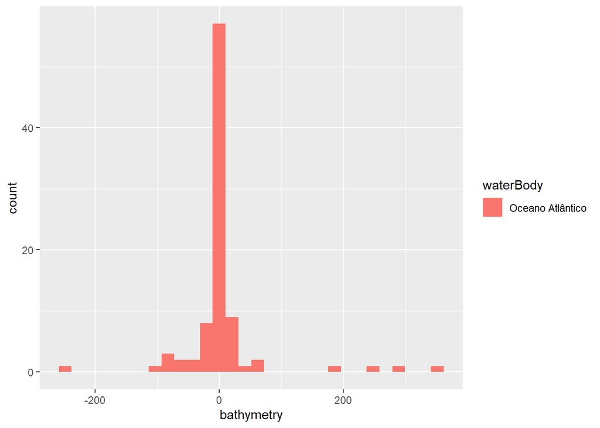

```r
# depth ok
lsub_obis1 %>%
  filter(!flags %in% c('no_depht', 'depth_exceeds_bath'),
         !is.na(datasetName)) %>%
  ggplot(aes(x = bathymetry, fill = waterBody)) +
  geom_histogram()
```

```r
# checar niveis
lsub_obis1 %>%
  filter(!flags %in% c('no_depht', 'depth_exceeds_bath'),
         !is.na(datasetName)) %>%
  lapply(., unique)
```

```
## $scientificName
## [1] "Lottia subrugosa"
##
## $decimalLatitude
##  [1] -34.664196  -9.507852 -23.966089 -23.073275 -22.966361 -22.953216
##  [7] -22.947783  -9.462858 -23.051333 -23.189472 -23.064392 -22.914038
## [13] -22.959968 -23.051096 -22.948262 -22.979444 -23.029296 -12.950106
## [19] -23.146248 -22.966089 -22.933531 -23.031378 -22.909171 -22.985333
## [25] -22.450794 -22.869573 -22.971377 -23.130858 -23.130541 -23.069393
## [31] -22.939632 -23.018030 -23.011896 -22.917726 -23.031250 -23.054250
## [37] -22.905513 -20.267271 -27.690929 -22.927747 -23.102463 -22.989916
## [43] -13.010158 -22.970653 -22.955262 -22.945634 -22.969938 -22.955295
## [49] -13.377105 -23.026144 -23.068031 -23.131089 -22.967888 -22.936934
## [55] -22.994944 -23.016611 -23.173405 -22.741431 -22.999407 -23.220375
## [61] -22.381637 -23.025472 -22.935141  -8.741271 -23.151222 -23.057663
```

[output cut: 143 more lines]

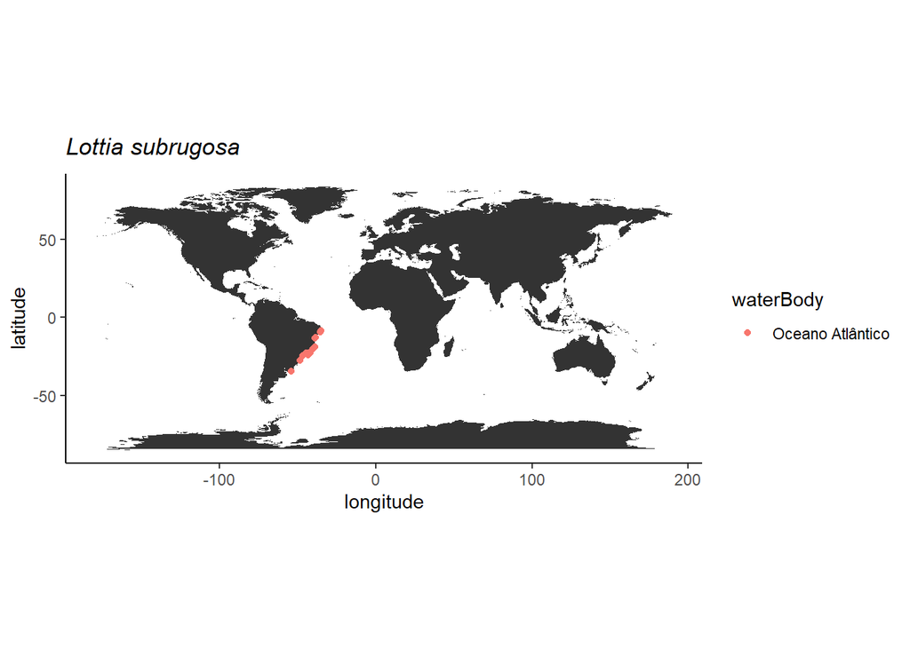

```r
# ok
lsub_obis_ok <- lsub_obis1 %>%
  filter(!flags %in% c('no_depht', 'depth_exceeds_bath'),
         !is.na(datasetName))
# check
ggplot() +
  geom_polygon(data = world, aes(x = long, y = lat, group = group)) +
  coord_fixed() +
  theme_classic() +
  geom_point(data = lsub_obis_ok, aes(x = decimalLongitude, y = decimalLatitude, color = waterBody)) +
  labs(x = "longitude", y = "latitude", title = expression(italic("Lottia subrugosa")))
```

### 3. UNINDO REPOSITÓRIOS Unindo dados baixados dos repositórios para checar duplas ocorrências

```r
setdiff(names(lsub_gbif_ok), names(lsub_obis_ok))
```

```
## [1] "acceptedScientificName" "issues"
```

```r
setdiff(names(lsub_obis_ok), names(lsub_gbif_ok))
```

```
## [1] "bathymetry" "flags"
```

```r
all_data <- bind_rows(lsub_gbif_ok %>%
                        mutate(repo = paste0("gbif", row.names(.))),
                      lsub_obis_ok %>%
                        mutate(repo = paste0("obis", row.names(.)))) %>%
  column_to_rownames("repo") %>%
  dplyr::select(decimalLongitude, decimalLatitude, depth) %>%
  distinct() %>%
  rownames_to_column("occ") %>%
  separate(col = "occ", into = c("datasetName", "rn"), sep = 4) %>%
  mutate(scientificName = "Lottia subrugosa") %>%
  dplyr::select(-rn)
```

Plotando utilizando o pacote `leaflet` para tornar o mapa interativo e conseguir um ajuste mais fino das ocorrências:

```r
library(leaflet)
```

```r
# conferir no mapa
all_data %>%
  leaflet() %>%
  addTiles() %>%
  addMarkers(~decimalLongitude,
             ~decimalLatitude)
```

[interactive chart not shown]

```r
pal <- colorFactor(palette = "viridis", domain = unique(all_data$scientificName))

all_data %>%
  rownames_to_column('id') %>%
  filter(!id %in% c("139", "1", '27', '86', '134', '129', '10', '14', '136', '90', '13')) %>%
  leaflet() %>%
  addTiles() %>%
  addCircleMarkers(~decimalLongitude,
                   ~decimalLatitude,
                   radius = 8,
                   label = ~as.character(id),
                   color = ~pal(all_data$scientificName),
                   stroke = FALSE, fillOpacity = 0.5) %>%
  addLegend('bottomright',
            colors = unique(pal(all_data$scientificName)),
            labels = unique(all_data$scientificName),
            title = 'Espécie',
            opacity = 0.5)
```

[interactive chart not shown]

Por fim, os dados foram guardados:

```r
write.csv(all_data, "atidade3_MarinaMega.csv", row.names = FALSE)
```

### 4. ANÁLISE EXPLORATÓRIA

Para a análise exploratória foi realizado um histograma a fim de verificar a distribuição latitudinal de *L. subrugosa*

```r
library(tidyverse)
library(viridis)
```

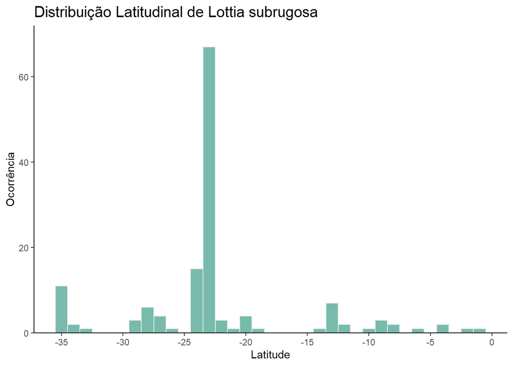

```r
hist<- all_data %>%
  ggplot( aes(x=decimalLatitude)) +
  geom_histogram( binwidth=1, fill="#69b3a2", color="#e9ecef", alpha=0.9) +
  ggtitle("Distribuição Latitudinal de Lottia subrugosa") +
  theme_classic()+
  labs(x="Latitude",
       y="Ocorrência") +
  scale_x_continuous(breaks = seq(-40, 0, 5)) +
  theme(
    plot.title = element_text(size=15)
  )

  hist + scale_y_continuous(expand = expansion(add = c(0,5)))
```

Verifique que a maior ocorrência da espécie ocorre próxima a latitude 23º, que compreende parte do litoral paulista (aproximadamente de Santos à Picinguaba) e parte do litoral fluminense (aproximadamente de Paraty à cidade do Rio de Janeiro). Podemos ver esse padrão, também, no mapa interativo acima, onde tem alta concentração de pontos especialmente na região de Angra dos Reis.